# Introduction to `R`

Víctor Peña

# Creating variables

We can create variables by assigning them values:

```r
firstvariable = 0
secondvariable = 10
thirdvariable = TRUE
fourthvariable = "hello"
```

If we want to print a variable, we can type its name. For example:

```r
fourthvariable
```

```
## [1] "hello"
```

We can see the “type” of the variables using the function `class`:

```r
class(firstvariable)
```

```
## [1] "numeric"
```

```r
class(thirdvariable)
```

```
## [1] "logical"
```

```r
class(fourthvariable)
```

```
## [1] "character"
```

The names of the types of these variables are pretty intuitive but here’s an explanation:

- `numeric` variables can take on numerical values
- `logical` variables can take on the values `TRUE` and `FALSE`
- `character` variables are characters

## Operations with variables

We can add, subtract, multiply, divide, and exponentiate `numeric` variables:

```r
firstvariable+secondvariable
```

```
## [1] 10
```

```r
firstvariable-secondvariable
```

```
## [1] -10
```

```r
firstvariable*secondvariable
```

```
## [1] 0
```

```r
firstvariable^secondvariable # exponentiation
```

```
## [1] 0
```

We can combine operations. For example, we can compute the average of `firstvariable` and `secondvariable` as

```r
(firstvariable+secondvariable)/2
```

```
## [1] 5
```

`R` has a built-in `mean` function, which we’ll see later.

We can’t add, subtract, multiply, divide or exponentiate `character` variables (try it out: it’ll give you an error), but we can add, subtract, multiply, divide or exponentiate `logical` variables. If the variable is `TRUE` it’ll be treated as a `1`; if it’s `FALSE`, it’ll be treated as a `0`:

```r
logi1 = TRUE
logi2 = FALSE
```

```r
logi1+logi2
```

```
## [1] 1
```

```r
logi1*logi2
```

```
## [1] 0
```

```r
logi1/logi2
```

```
## [1] Inf
```

```r
logi1^logi2
```

```
## [1] 1
```

We can combine `logical` and `numeric` variables in operations. Again, `TRUE` will be assigned `1`, and `FALSE` will be assigned `0`.

Finally, we can do operations without using variables at all:

```r
6/2*(2+1+TRUE)
```

```
## [1] 12
```

## Arithmetic functions

R has built-in functions such as `sqrt`, `exp`, `log`, …

```r
sqrt(4)
```

```
## [1] 2
```

```r
exp(firstvariable)
```

```
## [1] 1
```

```r
log(10, base=2)
```

```
## [1] 3.321928
```

If you’re not sure how a function works, you can ask for help by writing `?` before the name of the function.

# Vectors

We can define vectors as follows:

```r
x1 = c(1, 2, 3, 4, 5, 6)
y1 = c("a","b","c","d","efg")
z1 = c("a", 2, 3, "e")
```

And we can create ranges of values with `:`

```r
1:10
```

```
##  [1]  1  2  3  4  5  6  7  8  9 10
```

```r
10:6
```

```
## [1] 10  9  8  7  6
```

## Operations with vectors

We can add, multiply, divide, etc. all the components of a `numeric` vector by the same number:

```r
x1+5
```

```
## [1]  6  7  8  9 10 11
```

```r
x1*5
```

```
## [1]  5 10 15 20 25 30
```

```r
x1/5
```

```
## [1] 0.2 0.4 0.6 0.8 1.0 1.2
```

We can add and subtract vectors of the same length:

```r
x2 = c(7, 8, 9, 10, 11, 12)
x1+x2
```

```
## [1]  8 10 12 14 16 18
```

```r
x1-x2
```

```
## [1] -6 -6 -6 -6 -6 -6
```

Similarly, we can do **componentwise** multiplication and division:

```r
x1*x2
```

```
## [1]  7 16 27 40 55 72
```

```r
x1/x2
```

```
## [1] 0.1428571 0.2500000 0.3333333 0.4000000 0.4545455 0.5000000
```

If two vectors are of different lengths, we have to be careful! `R` won’t give us a warning message:

```r
x1
```

```
## [1] 1 2 3 4 5 6
```

```r
x3 = c(2,3)
x1+x3
```

```
## [1] 3 5 5 7 7 9
```

```r
x1*x3
```

```
## [1]  2  6  6 12 10 18
```

We can compute the dot product of 2 `numeric` vectors of the same length:

```r
t(x1)%*%x2
```

```
##      [,1]
## [1,]  217
```

We can compute means, standard deviations, variances, etc:

```r
mean(x1)
```

```
## [1] 3.5
```

```r
sd(x1)
```

```
## [1] 1.870829
```

```r
var(x1)
```

```
## [1] 3.5
```

## `length` and concatenating

We can find the length of a vector with `length`:

```r
length(x1)
```

```
## [1] 6
```

And we can add values to an existing vector as follows:

```r
x1
```

```
## [1] 1 2 3 4 5 6
```

```r
c(x1,10) # add at the end
```

```
## [1]  1  2  3  4  5  6 10
```

```r
c(10, x1) # add at the beginning
```

```
## [1] 10  1  2  3  4  5  6
```

We can concatenate vectors, too:

```r
c(x1, x2)
```

```
##  [1]  1  2  3  4  5  6  7  8  9 10 11 12
```

## Indexing vectors

We can look at particular entries of a vector using brackets.

```r
x1
```

```
## [1] 1 2 3 4 5 6
```

```r
x1[1] # first entry
```

```
## [1] 1
```

```r
x1[4] # 4th entry
```

```
## [1] 4
```

```r
x1[length(x1)] # last entry
```

```
## [1] 6
```

In `R`, indices start at `1` (in some other programming languages, indices start at `0`).

We can access subsets of vectors using vectors. For example, if we want to print the third and fifth entries of `x1`:

```r
x1[c(3,5)]
```

```
## [1] 3 5
```

We can subset using ranges of values with `:`. For instance, if we want to select the second, third, fourth, and fifth entries of `x1`:

```r
x1[2:5]
```

```
## [1] 2 3 4 5
```

# Matrices

We can create matrices as follows:

```r
A1 = matrix(c(1,2,3,4), nrow=2, ncol=2, byrow=TRUE) # read by row
A2 = matrix(c(1,3,2,4), nrow=2, ncol=2, byrow=FALSE) # read by column
```

Doing operations with matrices is straightforward:

```r
A1%*%A2 # matrix product
```

```
##      [,1] [,2]
## [1,]    7   10
## [2,]   15   22
```

```r
A1*A2 # componentwise product
```

```
##      [,1] [,2]
## [1,]    1    4
## [2,]    9   16
```

```r
A1+A2  # componentwise addition
```

```
##      [,1] [,2]
## [1,]    2    4
## [2,]    6    8
```

```r
log(A1) # taking the log of the components
```

```
##          [,1]      [,2]
## [1,] 0.000000 0.6931472
## [2,] 1.098612 1.3862944
```

Indexing matrices is similar to indexing vectors. For example, if we want to access the element in the first row and second column of `A1`:

```r
A1[1,2] # accessing entries: rows first, then columns
```

```
## [1] 2
```

You can also index by full rows and columns. For example, if you want to select the first row of `A1`:

```r
A1[1,]
```

```
## [1] 1 2
```

If you want to access the second column:

```r
A1[,2]
```

```
## [1] 2 4
```

# Installing libraries

Statisticians use `R` because there are many libraries that contain useful functions. We can install libraries with `install.packages`. For example, if we want to install `ggplot2`, which is a useful library for plotting:

```r
install.packages('ggplot2')
```

Once the library is installed, we can load it using `library()`. If we want to load `ggplot2`, we need to type:

```r
library(ggplot2)
```

# Introduction to `data.frame`s

We’ll use the dataset `mpg`, which is in the `ggplot2` library. First, we load it:

```r
data(mpg)
```

The class of the dataset is `data.frame` (and others), which are matrices that have columns that can have different types.

The function `str` gives us some information about the variables in the dataset:

```r
str(mpg)
```

```
## Classes 'tbl_df', 'tbl' and 'data.frame':    234 obs. of  11 variables:
##  $ manufacturer: chr  "audi" "audi" "audi" "audi" ...
##  $ model       : chr  "a4" "a4" "a4" "a4" ...
##  $ displ       : num  1.8 1.8 2 2 2.8 2.8 3.1 1.8 1.8 2 ...
##  $ year        : int  1999 1999 2008 2008 1999 1999 2008 1999 1999 2008 ...
##  $ cyl         : int  4 4 4 4 6 6 6 4 4 4 ...
##  $ trans       : chr  "auto(l5)" "manual(m5)" "manual(m6)" "auto(av)" ...
##  $ drv         : chr  "f" "f" "f" "f" ...
##  $ cty         : int  18 21 20 21 16 18 18 18 16 20 ...
##  $ hwy         : int  29 29 31 30 26 26 27 26 25 28 ...
##  $ fl          : chr  "p" "p" "p" "p" ...
##  $ class       : chr  "compact" "compact" "compact" "compact" ...
```

```r
head(mpg)
```

```
## # A tibble: 6 x 11
##   manufacturer model displ  year   cyl trans drv     cty   hwy fl    class
##   <chr>        <chr> <dbl> <int> <int> <chr> <chr> <int> <int> <chr> <chr>
## 1 audi         a4      1.8  1999     4 auto… f        18    29 p     comp…
## 2 audi         a4      1.8  1999     4 manu… f        21    29 p     comp…
## 3 audi         a4      2    2008     4 manu… f        20    31 p     comp…
## 4 audi         a4      2    2008     4 auto… f        21    30 p     comp…
## 5 audi         a4      2.8  1999     6 auto… f        16    26 p     comp…
## 6 audi         a4      2.8  1999     6 manu… f        18    26 p     comp…
```

```r
tail(mpg)
```

```
## # A tibble: 6 x 11
##   manufacturer model displ  year   cyl trans drv     cty   hwy fl    class
##   <chr>        <chr> <dbl> <int> <int> <chr> <chr> <int> <int> <chr> <chr>
## 1 volkswagen   pass…   1.8  1999     4 auto… f        18    29 p     mids…
## 2 volkswagen   pass…   2    2008     4 auto… f        19    28 p     mids…
## 3 volkswagen   pass…   2    2008     4 manu… f        21    29 p     mids…
## 4 volkswagen   pass…   2.8  1999     6 auto… f        16    26 p     mids…
## 5 volkswagen   pass…   2.8  1999     6 manu… f        18    26 p     mids…
## 6 volkswagen   pass…   3.6  2008     6 auto… f        17    26 p     mids…
```

We can index the rows and columns of `mpg` using the same syntax we used for indexing matrices:

```r
mpg[3:7,c(1,4:5)]
```

```
## # A tibble: 5 x 3
##   manufacturer  year   cyl
##   <chr>        <int> <int>
## 1 audi          2008     4
## 2 audi          2008     4
## 3 audi          1999     6
## 4 audi          1999     6
## 5 audi          2008     6
```

With `data.frame`s we can extract variables using `$`. For example, if we want to look at `year`:

```r
mpg$year
```

```
##   [1] 1999 1999 2008 2008 1999 1999 2008 1999 1999 2008 2008 1999 1999 2008
##  [15] 2008 1999 2008 2008 2008 2008 2008 1999 2008 1999 1999 2008 2008 2008
##  [29] 2008 2008 1999 1999 1999 2008 1999 2008 2008 1999 1999 1999 1999 2008
##  [43] 2008 2008 1999 1999 2008 2008 2008 2008 1999 1999 2008 2008 2008 1999
##  [57] 1999 1999 2008 2008 2008 1999 2008 1999 2008 2008 2008 2008 2008 2008
##  [71] 1999 1999 2008 1999 1999 1999 2008 1999 1999 1999 2008 2008 1999 1999
##  [85] 1999 1999 1999 2008 1999 2008 1999 1999 2008 2008 1999 1999 2008 2008
##  [99] 2008 1999 1999 1999 1999 1999 2008 2008 2008 2008 1999 1999 2008 2008
## [113] 1999 1999 2008 1999 1999 2008 2008 2008 2008 2008 2008 2008 1999 1999
## [127] 2008 2008 2008 2008 1999 2008 2008 1999 1999 1999 2008 1999 2008 2008
## [141] 1999 1999 1999 2008 2008 2008 2008 1999 1999 2008 1999 1999 2008 2008
## [155] 1999 1999 1999 2008 2008 1999 1999 2008 2008 2008 2008 1999 1999 1999
## [169] 1999 2008 2008 2008 2008 1999 1999 1999 1999 2008 2008 1999 1999 2008
## [183] 2008 1999 1999 2008 1999 1999 2008 2008 1999 1999 2008 1999 1999 1999
## [197] 2008 2008 1999 2008 1999 1999 2008 1999 1999 2008 2008 1999 1999 2008
## [211] 2008 1999 1999 1999 1999 2008 2008 2008 2008 1999 1999 1999 1999 1999
## [225] 1999 2008 2008 1999 1999 2008 2008 1999 1999 2008
```

We can also index by logical conditions. For instance, if we want to work with the subset of Toyota cars:

```r
mpg[mpg$manufacturer == "toyota",]
```

```
## # A tibble: 34 x 11
##    manufacturer model displ  year   cyl trans drv     cty   hwy fl    cla…
##    <chr>        <chr> <dbl> <int> <int> <chr> <chr> <int> <int> <chr> <ch>
##  1 toyota       4run…   2.7  1999     4 manu… 4        15    20 r     suv
##  2 toyota       4run…   2.7  1999     4 auto… 4        16    20 r     suv
##  3 toyota       4run…   3.4  1999     6 auto… 4        15    19 r     suv
##  4 toyota       4run…   3.4  1999     6 manu… 4        15    17 r     suv
##  5 toyota       4run…   4    2008     6 auto… 4        16    20 r     suv
##  6 toyota       4run…   4.7  2008     8 auto… 4        14    17 r     suv
##  7 toyota       camry   2.2  1999     4 manu… f        21    29 r     mid…
##  8 toyota       camry   2.2  1999     4 auto… f        21    27 r     mid…
##  9 toyota       camry   2.4  2008     4 manu… f        21    31 r     mid…
## 10 toyota       camry   2.4  2008     4 auto… f        21    31 r     mid…
## # ... with 24 more rows
```

# Factors

`factor` is a variable type in `R` useful for encoding categorical variables. Defining them is easy:

```r
fac1 = factor(c("dog","cat","cat","dog"))
```

We can use `summary` to create a quick table (note that `summary` didn’t work well with `character` variables):

```r
summary(fac1)
```

```
## cat dog
##   2   2
```

The default ordering of the categories in a factor is alphabetical, which isn’t always the best or most intutive. We can see the different categories (in `R` lingo, levels) of a factor and its ordering using `levels`:

```r
levels(fac1)
```

```
## [1] "cat" "dog"
```

Let’s use the `hsb2` dataset (on the course website) to illustrate this point. The dataset contains a variable called `ses`, which is socioeconomic status of the student. It can take on the values `low`, `middle`, and `high`. Unfortunately, the default ordering of the factor is alphabetical, that is:

```r
levels(hsb2$ses)
```

```
## [1] "high"   "low"    "middle"
```

```r
table(hsb2$ses, hsb2$race)
```

```
##
##          african american asian hispanic white
##   high                  3     3        4    48
##   low                  11     3        9    24
##   middle                6     5       11    73
```

This is not great.

How can we reorder the levels of a factor? The answer is

```r
hsb2$ses = factor(hsb2$ses, ordered = TRUE, levels = c("low", "middle", "high"))
```

The code above rewrites the `ses` variable in `hsb2` to an ordered factor whose levels are `low`, `middle`, and `high` (in that order).

If you don’t believe me (and you shouldn’t), here’s the code to verify that `ses` is now ordered:

```r
levels(hsb2$ses)
```

```
## [1] "low"    "middle" "high"
```

```r
table(hsb2$ses, hsb2$race)
```

```
##
##          african american asian hispanic white
##   low                  11     3        9    24
##   middle                6     5       11    73
##   high                  3     3        4    48
```

# Lists

We won’t say much about `list`s, but they’re useful if we want to keep objects of different types in a single place.

For example, suppose that we have a `vector` and a `matrix`:

```r
v = 1:6
m = matrix(c(1,0,0,1),byrow=T,nrow=2)
```

Then, the following code creates a `list` whose entries are the vector `v` and the matrix `m`:

```r
l = list(v,m)
```

We can access, say, the second element of the list with

```r
l[[2]]
```

```
##      [,1] [,2]
## [1,]    1    0
## [2,]    0    1
```

And we can do things such as

```r
l[[2]][2,1]
```

```
## [1] 0
```

```r
l[[1]][4]
```

```
## [1] 4
```

We can add a new element to the list indexing by a new element

```r
v2 = 3:4
l[[3]] = v2
```

We probably won’t see `list`s again in the course, but it’s good to know that they exist.

# Basic data summaries with `R`

We can get quick summaries of `numeric` variables with `summary`

```r
summary(mpg)
```

```
##  manufacturer          model               displ            year
##  Length:234         Length:234         Min.   :1.600   Min.   :1999
##  Class :character   Class :character   1st Qu.:2.400   1st Qu.:1999
##  Mode  :character   Mode  :character   Median :3.300   Median :2004
##                                        Mean   :3.472   Mean   :2004
##                                        3rd Qu.:4.600   3rd Qu.:2008
##                                        Max.   :7.000   Max.   :2008
##       cyl           trans               drv                 cty
##  Min.   :4.000   Length:234         Length:234         Min.   : 9.00
##  1st Qu.:4.000   Class :character   Class :character   1st Qu.:14.00
##  Median :6.000   Mode  :character   Mode  :character   Median :17.00
##  Mean   :5.889                                         Mean   :16.86
##  3rd Qu.:8.000                                         3rd Qu.:19.00
##  Max.   :8.000                                         Max.   :35.00
##       hwy             fl               class
##  Min.   :12.00   Length:234         Length:234
##  1st Qu.:18.00   Class :character   Class :character
##  Median :24.00   Mode  :character   Mode  :character
##  Mean   :23.44
##  3rd Qu.:27.00
##  Max.   :44.00
```

We can tabulate with `table`

```r
table(mpg$manufacturer)
```

```
##
##       audi  chevrolet      dodge       ford      honda    hyundai
##         18         19         37         25          9         14
##       jeep land rover    lincoln    mercury     nissan    pontiac
##          8          4          3          4         13          5
##     subaru     toyota volkswagen
##         14         34         27
```

```r
table(mpg$manufacturer,mpg$year)
```

```
##
##              1999 2008
##   audi          9    9
##   chevrolet     7   12
##   dodge        16   21
##   ford         15   10
##   honda         5    4
##   hyundai       6    8
##   jeep          2    6
##   land rover    2    2
##   lincoln       2    1
##   mercury       2    2
##   nissan        6    7
##   pontiac       3    2
##   subaru        6    8
##   toyota       20   14
##   volkswagen   16   11
```

```r
table(mpg$year)
```

```
##
## 1999 2008
##  117  117
```

We can plot stuff, too. For example, `hist` does histograms:

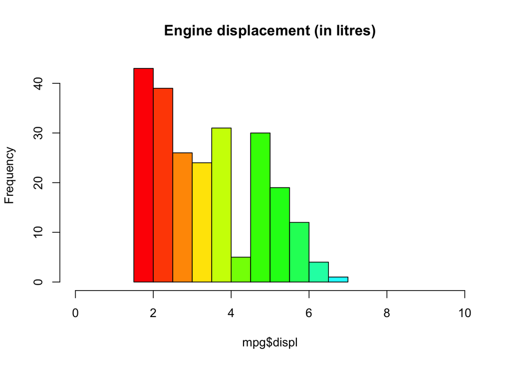

```r
hist(mpg$displ, main="Engine displacement (in litres)",
     col=rainbow(20),
     xlim=c(0,10))
```

You can learn more about how to change the attributes of the plot with `?hist`.

We can create individual boxplots and boxplots grouped by values of categorical variables:

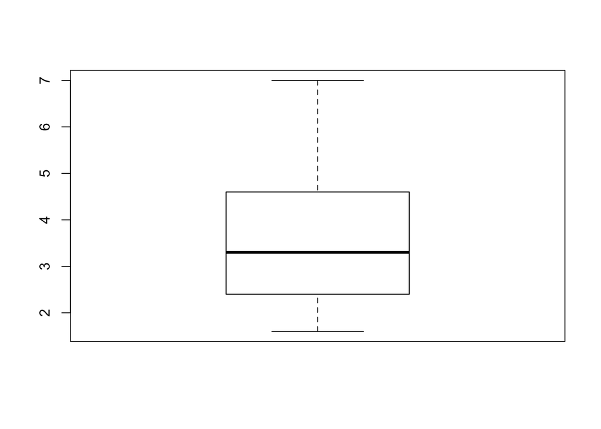

```r
boxplot(mpg$displ)
```

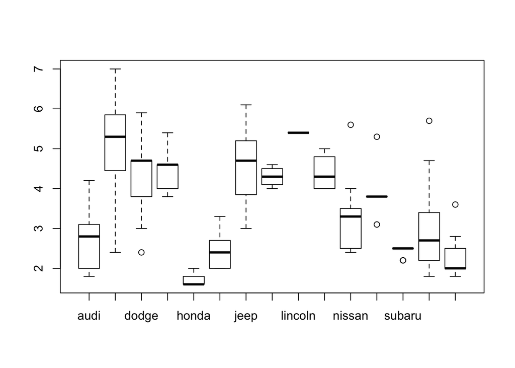

```r
boxplot(mpg$displ~mpg$manufacturer)
```

These plots are created using the `graphics` library. There are other libraries that you can use to produce plots. One of them is `ggplot2`, which we installed earlier. A nice thing about `ggplot2` is that it has the function `qplot`, which produces good-looking plots by default. For example:

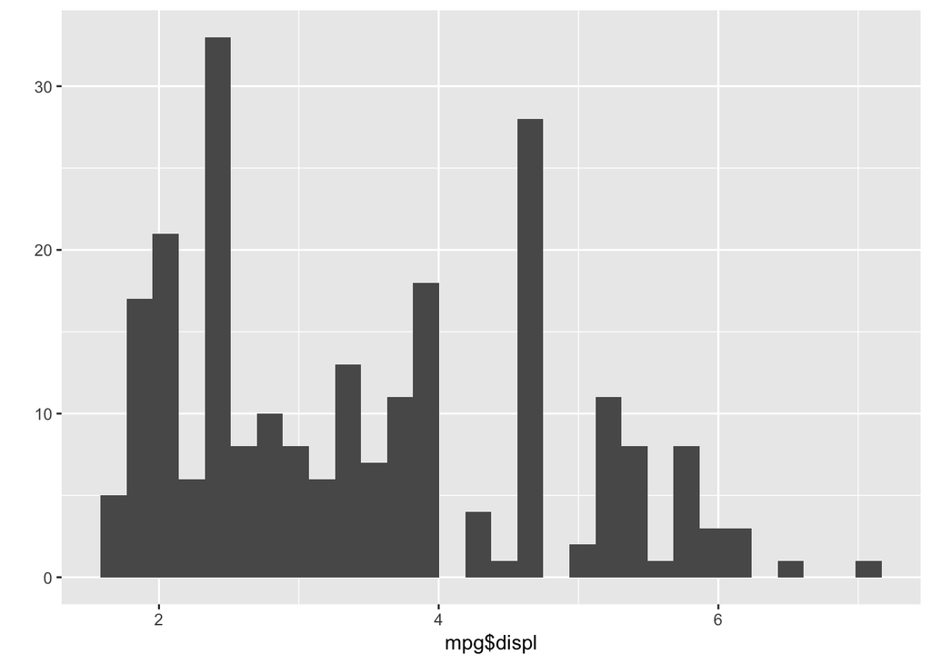

```r
qplot(mpg$displ)
```

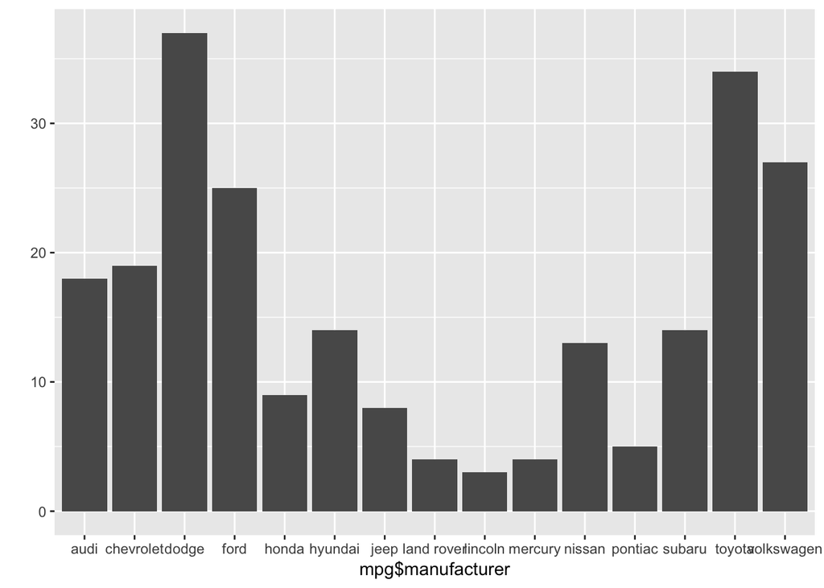

```r
qplot(mpg$manufacturer)
```

`qplot` is smart enough to produce different plots depending on the type of the object. We’ll cover `ggplot2` in more detail later in the semester.

# Sources

- [Datacamp: introduction to `R`](https://www.datacamp.com/courses/free-introduction-to-r)